# NFL Stats by Division

Audrey & Nathan

6/14/19

# Introduction

- NFL summary data –> 2009 - 2018

### Focus: “Competitiveness” across the NFL

- Distributions of team success over time
- Differences across divisions (AFC vs NFC)
- Similarities in play styles (pass/run and offense/defense)
- Historical consistency of teams – how likely are upsets?

# Data

- NFL season summaries from 2009 - 2018

### Identifying info:

- team name
- season
- division

### Outcome variables

- wins/losses/ties
- points scored
- points allowed

# Data

### Offense / Defense Stats

- offensive points made
- expected points
- defensive points made
- expected defensive points
- broken up two ways:
  - passing vs running plays
  - per attempt vs total across season

# Manipulation: Creating New Variables

- more general divisions (removing north/south/east/west)
- win / loss ratio (wins / losses per season)
- win record (double positive, positive, negative) based on win / loss ratio
- avg points scored per game
- avg points allowed per game
- total offensive yards gained
- total defensive yards allowed

## Question 1: Divisions

- 2 Major Divisions:
  - National Football Conference (NFC)
  - American Football Conference (AFC)
- Is either division becoming more competitive over time (fewer outlier teams)?
- Does either division appear to have clear dominant teams, or do a variety of teams take the spotlight in different years?

## Are there clear dominant teams, or are victories spread out across teams?

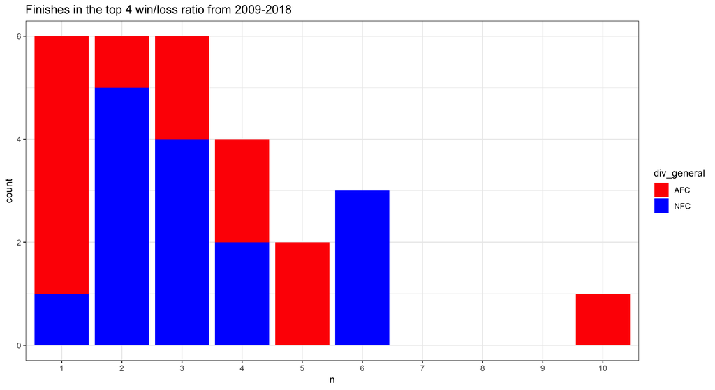

```r
library(cowplot)
library(magick)
top_teams_by_year %>%
    group_by(team, div_general) %>%
    summarise(n = n()) %>%
    mutate(n = factor(n, levels = 1:10)) %>%
    ggplot(aes(x = n)) +
        geom_bar(aes(fill = div_general)) +
        scale_fill_manual(drop = F, values = c("red", "blue")) +
        scale_x_discrete(drop=FALSE) +
        # facet_wrap(~div_general) +
        labs(title = "Finishes in the top 4 win/loss ratio from 2009-2018") +
        theme_bw() -> plt
plt
```

[figure not shown]

```r
sv <- 0.09
jaguars <-  "http://loodibee.com/wp-content/uploads/nfl-jacksonville-jaguars-team-logo-2-768x768.png"
chargers <- "http://loodibee.com/wp-content/uploads/nfl-los-angeles-chargers-team-logo-2-768x768.png"
jets <- "http://loodibee.com/wp-content/uploads/nfl-new-york-jets-team-logo-768x768.png"
raiders <- "http://loodibee.com/wp-content/uploads/nfl-oakland-raiders-team-logo-768x768.png"
ravens <- "http://loodibee.com/wp-content/uploads/nfl-baltimore-ravens-team-logo-2-768x768.png"
bengals <- "http://loodibee.com/wp-content/uploads/nfl-cincinnati-bengals-team-logo-768x768.png"
texans <- "http://loodibee.com/wp-content/uploads/nfl-houston-texans-team-logo-2-768x768.png"

x <- seq(from = -0.405, to = 0.6, by = 0.079)

ggdraw() +
    draw_plot(plt) +
    draw_image(jaguars, x = x[1], y = 0.27, scale = sv) +
    draw_image(chargers, x = x[1], y = 0.13, scale = sv) +
    draw_image(jets, x = x[1], y = -0.01, scale = sv) +
    draw_image(raiders, x = x[1], y = -0.15, scale = sv) +
    draw_image(chargers, x = x[1], y = -0.29, scale = sv) +
    draw_image(ravens, x = x[2], y = -0.29, scale = sv) +
    draw_image(bengals, x = x[3], y = -0.15, scale = sv) +
    draw_image(texans, x = x[3], y = -0.29, scale = sv) +
    draw_image(texans, x = x[4], y = -0.29, scale = sv) +
    draw_image(texans, x = x[5], y = -0.29, scale = sv) +
    draw_image(texans, x = x[6], y = -0.29, scale = sv) +
    draw_image(texans, x = x[10], y = -0.29, scale = sv)
```

```r
top_teams_by_year %>%
    group_by(team, div_general) %>%
    summarise(n = n()) %>%
    filter(div_general == "AFC") %>%
    arrange(n)
```

```
## # A tibble: 13 x 3
## # Groups:   team [13]
##    team  div_general     n
##    <chr> <chr>       <int>
##  1 JAX   AFC             1
##  2 LAC   AFC             1
##  3 NYJ   AFC             1
##  4 OAK   AFC             1
##  5 SD    AFC             1
##  6 BAL   AFC             2
##  7 CIN   AFC             3
##  8 HOU   AFC             3
##  9 DEN   AFC             4
## 10 IND   AFC             4
## 11 KC    AFC             5
## 12 PIT   AFC             5
## 13 NE    AFC            10
```

## Takeaways - Divisions

## Question 2: Pass/Run

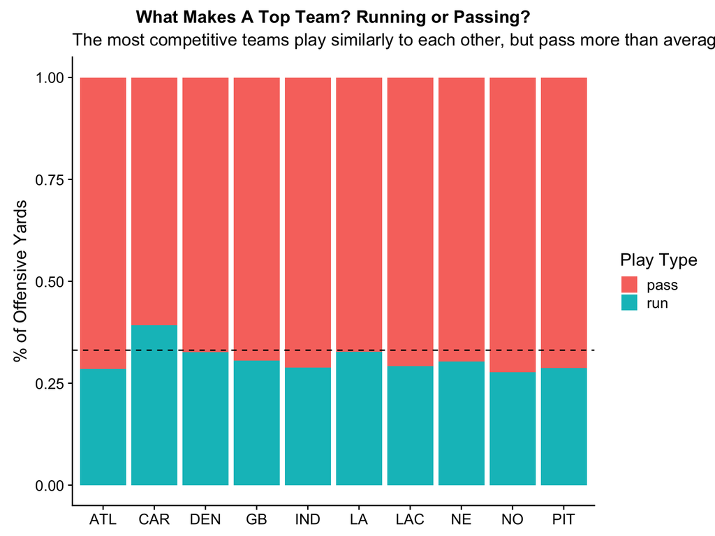

## Takeaways - Passing vs Running

## Question 3: Offense/Defense

```
## # A tibble: 6 x 29
##   team  season points_scored points_allowed  wins losses  ties
##   <chr>  <dbl>         <dbl>          <dbl> <dbl>  <dbl> <dbl>
## 1 PIT     2009           368            324     9      7     0
## 2 PIT     2010           375            232    12      4     0
## 3 PIT     2011           325            227    12      4     0
## 4 PIT     2012           336            314     8      8     0
## 5 PIT     2013           379            370     8      8     0
## 6 PIT     2014           436            368    11      5     0
## # … with 22 more variables: pass_off_epa_per_att <dbl>,
## #   pass_off_total_epa <dbl>, pass_off_total_yards_gained <dbl>,
## #   pass_off_yards_gained_per_att <dbl>, run_off_epa_per_att <dbl>,
## #   run_off_total_epa <dbl>, run_off_total_yards_gained <dbl>,
## #   run_off_yards_gained_per_att <dbl>, pass_def_epa_per_att <dbl>,
## #   pass_def_total_epa <dbl>, pass_def_total_yards_allowed <dbl>,
## #   pass_def_yards_allowed_per_att <dbl>, run_def_epa_per_att <dbl>,
## #   run_def_total_epa <dbl>, run_def_total_yards_allowed <dbl>,
## #   run_def_yards_allowed_per_att <dbl>, division <chr>,
## #   div_general <chr>, WLRatio <dbl>, record <fct>,
## #   total_offensive_gained <dbl>, total_defensive_allowed <dbl>
```

[interactive chart not shown]

## Takeaways - Offense vs Defense

## Question 4: Consistency

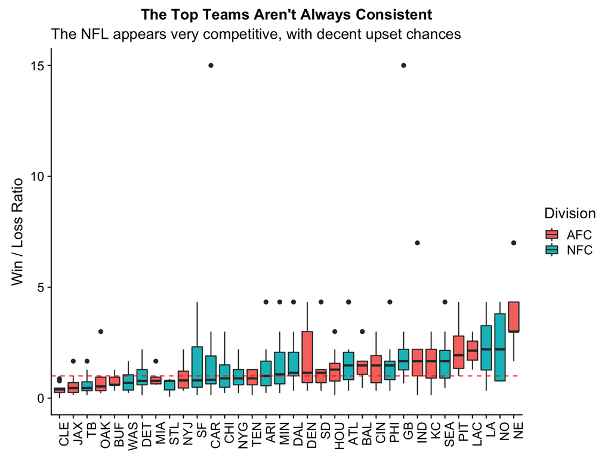